# Презентация по лабораторной работе №8

Математическое моделирование

Арбатова Варвара Петровна

1132236020@rudn.ru

Российский университет дружбы народов

2026-05-19

# Цель работы

Исследовать простейшую математическую модель конкуренции двух фирм.

# Задание

## Вариант 21

**Случай 1.** Рассмотрим две фирмы, производящие взаимозаменяемые товары одинакового качества и находящиеся в одной рыночной нише. Динамика изменения объемов продаж описывается системой:

$$\begin{cases}
\dfrac{dM_1}{d\theta} = M_1-\dfrac{b}{c_1}M_1M_2-\dfrac{a_1}{c_1}M_1^2,\\[10pt]
\dfrac{dM_2}{d\theta} = \dfrac{c_2}{c_1}M_2-\dfrac{b}{c_1}M_1M_2-\dfrac{a_2}{c_1}M_2^2,
\end{cases}$$

где $a_1=\dfrac{p_{cr}}{\tau_{1}^2\tilde p_1^2Nq}$, $a_2=\dfrac{p_{cr}}{\tau_{2}^2\tilde p_2^2Nq}$, $b=\dfrac{p_{cr}}{\tau_{1}^2\tilde p_1^2\tau_{2}^2\tilde p_2^2Nq}$, $c_1=\dfrac{p_{cr} - \tilde{p_1}}{\tau_{1}\tilde p_1}$, $c_2=\dfrac{p_{cr} - \tilde{p_1}}{\tau_{2}\tilde p_2}$.

Также введена нормировка $t=c_1\theta$.

## Случай 2

**Случай 2.** Рассмотрим модель с социально-психологическими факторами. Система уравнений:

$$\begin{cases}
\dfrac{dM_1}{d\theta} = M_1-\dfrac{b}{c_1}M_1M_2-\dfrac{a_1}{c_1}M_1^2,\\[10pt]
\dfrac{dM_2}{d\theta} = \dfrac{c_2}{c_1}M_2-\left(\dfrac{b}{c_1}+0.00083\right)M_1M_2-\dfrac{a_2}{c_1}M_2^2,
\end{cases}$$

## Начальные условия и параметры

Для обоих случаев:

$$M_1(0)=7, \quad M_2(0)=8, \quad p_{cr}=45, \quad N=70, \quad q=1,$$
$$\tau_1=25, \quad \tau_2=20, \quad \tilde{p_1}=10, \quad \tilde{p_2}=7.7$$

## Обозначения

- $N$ – число потребителей
- $\tau$ – длительность производственного цикла
- $p$ – рыночная цена товара
- $\tilde{p}$ – себестоимость продукта
- $q$ – максимальная потребность одного человека в продукте в единицу времени

## Задачи

1. Построить графики изменения оборотных средств для случая 1
2. Построить графики изменения оборотных средств для случая 2
3. Найти стационарное состояние системы для первого случая

# Выполнение

## Параметры модели в Julia

```julia
using DifferentialEquations, Plots
p_cr = 45; tau1 = 25; p1 = 10.0
tau2 = 20; p2 = 7.7; N = 70; q = 1
a1 = p_cr/(tau1^2*p1^2*N*q)
a2 = p_cr/(tau2^2*p2^2*N*q)
b = p_cr/(tau1^2*tau2^2*p1^2*p2^2*N*q)
c1 = (p_cr-p1)/(tau1*p1)
c2 = (p_cr-p2)/(tau2*p2)
u0 = [7.0, 8.0]
p = [a1, a2, b, c1, c2]
tspan = (0.0, 50.0)
```

## Случай 1: функция и стационарное состояние

```julia
function f(u, p, t)
    M1, M2 = u
    a1, a2, b, c1, c2 = p
    dM1 = M1 - (a1/c1)*M1^2 - (b/c1)*M1*M2
    dM2 = (c2/c1)*M2 - (a2/c1)*M2^2 - (b/c1)*M1*M2
    return [dM1, dM2]
end

using LinearAlgebra
A = [(a1/c1) (b/c1); (b/c1) (a2/c1)]
b1 = [1, (c2/c1)]
x = A \ b1
```

Стационарное состояние: $M_1^* = 13610.73$, $M_2^* = 8935.20$

## График для случая 1

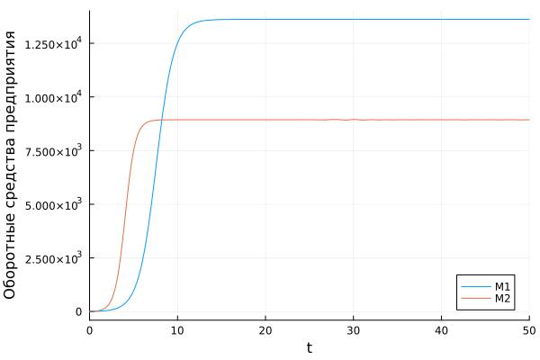

Рисунок 1: График для случая 1

```julia
prob = ODEProblem(f, u0, tspan, p)
sol = solve(prob, Tsit5(), saveat = 0.01)
plot(sol, yaxis="Оборотные средства", label=["M1" "M2"])
```

## Случай 2: функция

```julia
function f2(u, p, t)
    M1, M2 = u
    a1, a2, b, c1, c2 = p
    dM1 = M1 - (a1/c1)*M1^2 - (b/c1)*M1*M2
    dM2 = (c2/c1)*M2 - (a2/c1)*M2^2 - (b/c1+0.00083)*M1*M2
    return [dM1, dM2]
end
```

## График для случая 2

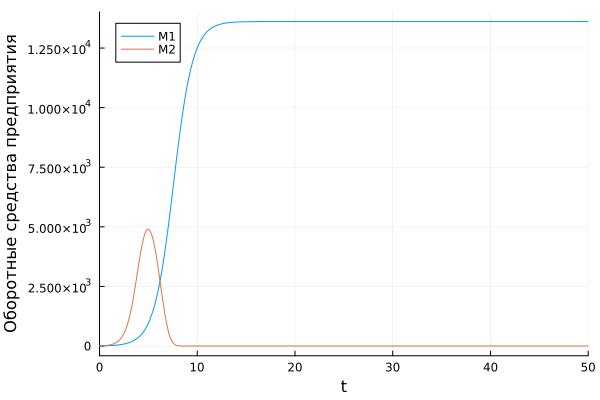

Рисунок 2: График для случая 2

```julia
prob2 = ODEProblem(f2, u0, tspan, p)
sol2 = solve(prob2, Tsit5(), saveat = 0.01)
plot(sol2, yaxis="Оборотные средства", label=["M1" "M2"])
```

## Детальный график для случая 2

[figure not shown]

```julia
plot(sol2, yaxis="Оборотные средства", label=["M1" "M2"],
     ylimit=[0, 20], xlimit=[0, 12])
```

Вторая фирма, достигнув максимума, начинает нести убытки и терпит банкротство. Первая фирма остается на максимальном уровне.

# Выводы

Построили математическую модель конкуренции двух фирм. Исследовали два случая: без социально-психологических факторов и с ними. Нашли стационарное состояние системы.